# Business Problem

Airline companies need to optimize operations and terminal usage to improve passenger satisfaction and maximize revenue. Understanding travel patterns and customer demand will allow airlines to segment operations for better efficiency.

# High level Solution

Apply hierarchical clustering on airline passenger data to identify patterns in travel behavior, segment airlines/terminals, and provide actionable insights for operational optimization.

**Objective:** Maximize the operational efficiency

**Constraints:** Maximize the financial health

# Success Criteria:

- Business Success: Increase operational efficiency by 10–12% through airline segmentation.
- ML Success: Achieve a Silhouette coefficient ≥ 0.7.
- Economic Success: Hypothetical increase in airline revenues by ≥ 8%.

# Data Dictionary

| Field | Description | Variable Type | Scale | Example Value | Additional Information |
| --- | --- | --- | --- | --- | --- |
| Activity Period | Unique Period identifier (YYYYMM) | continuous | Interval | 200507 | Represented Year and Month combined (e.g:,200507 = July 2005) |
| Operating Airline | Name of the airline | Discrete | Nominal | ATA Airlines | Airline Company Operating the Flight |
| Operating Airline IATA Code | IATA code of the airline | Discrete | Nominal | TZ | Two-character Airline code |
| GEO Region | Geographic region of operation | Discrete | Nominal | US | Region code (e.g., US, International, Asia, etc.) |
| Terminal | Airport Terminal | Discrete | Nominal | Terminal 1 | Terminal used for boarding/departure |
| Boarding Area | Boarding Gate/Area in Terminal | Discrete | Nominal | B | Subdivison Of terimanal |
| Passenger Count | Number of Passengers | Continuous | Ratio | 27,271 | Non-negative integer, zero is meanigful |
| Year | Year Of Operation | Continuous | Interval | 2005 | Extracted From Activity Period |
| Month | Month Of Operation | Discrete | Ordinal | July | Names of months, Natural order (Jan - Dec) |

| 15007 x 9 |
| --- |

# Install the required packages if not present already

- pip install sweetviz
- pip install py-AutoClean
- pip install clusteval
- pip install sqlalchemy
- pip install pymysql

```python
# Importing required packages
import pandas as pd # Importing pandas for data manipulation
import numpy as np # Importing numpy for numerical calculation
import matplotlib.pyplot as plt  # Importing matplot for visualizzation
```

```python
from sqlalchemy import create_engine, text # Importing create_engine and text for sql interaction
from urllib.parse import quote_plus # Importing quote_plus for encoding the special character
```

```python
import seaborn as sns # Importing seaborn for Adv. visualization
from scipy import stats # Importing stats for statistcall calculation
from scipy.stats import skew, kurtosis # Importing skew and Kurtosis to Skewness and kurtosis
from sklearn.pipeline import Pipeline # Importing pipeline for to make pipeline
```

```python
from feature_engine.outliers.winsorizer import Winsorizer # Importing Winsorization for Outlier treatment
from sklearn.preprocessing import StandardScaler # Importing Standard scaler for standardization
from sklearn.preprocessing import LabelEncoder # Importing LabelEncoder to covert categorical(ordinal) to numerical data
from sklearn.preprocessing import OneHotEncoder # Importing OneHotEncoder to covert categorical(nominal) to numerical data
from sklearn.compose import ColumnTransformer # Importing ColumnTransformer to transfer pipelines into the data
from scipy.cluster.hierarchy import linkage, dendrogram  # Importing functions for hierarchical clustering
from sklearn.cluster import AgglomerativeClustering as aglo # Importing AgglomerativeClustering for hierarchical clustering as aglo
from sklearn import metrics  # Importing metrics module from scikit-learn for evaluating clustering performance
```

```python
air_trafic = pd.read_csv(r"C:\Users\ASUS\OneDrive\Desktop\360digiTMG\Model Building\Dataset\AirTraffic_Passenger_Statistics.csv") #load the data set from local machine
```

```python
#all credential for sql conncetion
user = 'Anshuman'
pw = 'Anshu@1004'
db = 'Airline_Traffic'

#Convert special charater
pw = quote_plus(pw)

#Establish connection with db
engine = create_engine(f"mysql+pymysql://{user}:{pw}@localhost/{db}")
```

```python
#load data set to MySQL
air_trafic.to_sql('Airline_traffic', con = engine, if_exists = 'replace', chunksize = 1000, index = False)
```

```python
#Read data from MySQL and load in dataframe
sql = 'Select * from Airline_traffic;'
df = pd.read_sql_query(text(sql), engine.connect())

df
```

|  | Activity Period | Operating Airline | Operating Airline IATA Code | GEO Region | Terminal | Boarding Area | Passenger Count | Year | Month |
| --- | --- | --- | --- | --- | --- | --- | --- | --- | --- |
| 0 | 200507 | ATA Airlines | TZ | US | Terminal 1 | B | 27271 | 2005 | July |
| 1 | 200507 | ATA Airlines | TZ | US | Terminal 1 | B | 29131 | 2005 | July |
| 2 | 200507 | ATA Airlines | TZ | US | Terminal 1 | B | 5415 | 2005 | July |
| 3 | 200507 | Air Canada | AC | Canada | Terminal 1 | B | 35156 | 2005 | July |
| 4 | 200507 | Air Canada | AC | Canada | Terminal 1 | B | 34090 | 2005 | July |
| ... | ... | ... | ... | ... | ... | ... | ... | ... | ... |
| 15002 | 201603 | Virgin America | VX | US | Terminal 2 | D | 194636 | 2016 | March |
| 15003 | 201603 | Virgin America | VX | Mexico | International | A | 4189 | 2016 | March |
| 15004 | 201603 | Virgin America | VX | Mexico | Terminal 2 | D | 4693 | 2016 | March |
| 15005 | 201603 | Virgin Atlantic | VS | Europe | International | A | 12313 | 2016 | March |
| 15006 | 201603 | Virgin Atlantic | VS | Europe | International | A | 10898 | 2016 | March |

15007 rows × 9 columns

```python
#first 5 records
df.head()
```

|  | Activity Period | Operating Airline | Operating Airline IATA Code | GEO Region | Terminal | Boarding Area | Passenger Count | Year | Month |
| --- | --- | --- | --- | --- | --- | --- | --- | --- | --- |
| 0 | 200507 | ATA Airlines | TZ | US | Terminal 1 | B | 27271 | 2005 | July |
| 1 | 200507 | ATA Airlines | TZ | US | Terminal 1 | B | 29131 | 2005 | July |
| 2 | 200507 | ATA Airlines | TZ | US | Terminal 1 | B | 5415 | 2005 | July |
| 3 | 200507 | Air Canada | AC | Canada | Terminal 1 | B | 35156 | 2005 | July |
| 4 | 200507 | Air Canada | AC | Canada | Terminal 1 | B | 34090 | 2005 | July |

```python
#last 5 records
df.tail()
```

|  | Activity Period | Operating Airline | Operating Airline IATA Code | GEO Region | Terminal | Boarding Area | Passenger Count | Year | Month |
| --- | --- | --- | --- | --- | --- | --- | --- | --- | --- |
| 15002 | 201603 | Virgin America | VX | US | Terminal 2 | D | 194636 | 2016 | March |
| 15003 | 201603 | Virgin America | VX | Mexico | International | A | 4189 | 2016 | March |
| 15004 | 201603 | Virgin America | VX | Mexico | Terminal 2 | D | 4693 | 2016 | March |
| 15005 | 201603 | Virgin Atlantic | VS | Europe | International | A | 12313 | 2016 | March |
| 15006 | 201603 | Virgin Atlantic | VS | Europe | International | A | 10898 | 2016 | March |

```python
#information about the dataframe
df.info()
```

```
<class 'pandas.core.frame.DataFrame'>
RangeIndex: 15007 entries, 0 to 15006
Data columns (total 9 columns):
 #   Column                       Non-Null Count  Dtype
---  ------                       --------------  -----
 0   Activity Period              15007 non-null  int64
 1   Operating Airline            15007 non-null  object
 2   Operating Airline IATA Code  14953 non-null  object
 3   GEO Region                   15007 non-null  object
 4   Terminal                     15007 non-null  object
 5   Boarding Area                15007 non-null  object
 6   Passenger Count              15007 non-null  int64
 7   Year                         15007 non-null  int64
 8   Month                        15007 non-null  object
dtypes: int64(3), object(6)
memory usage: 1.0+ MB
```

> There is some null values in Operating Airline IATA Code

```python
df.describe() # Generating descriptive statistics of the DataFrame 'df', including count, mean, std, min, max, etc.
```

|  | Activity Period | Passenger Count | Year |
| --- | --- | --- | --- |
| count | 15007.000000 | 15007.000000 | 15007.000000 |
| mean | 201045.073366 | 29240.521090 | 2010.385220 |
| std | 313.336196 | 58319.509284 | 3.137589 |
| min | 200507.000000 | 1.000000 | 2005.000000 |
| 25% | 200803.000000 | 5373.500000 | 2008.000000 |
| 50% | 201011.000000 | 9210.000000 | 2010.000000 |
| 75% | 201308.000000 | 21158.500000 | 2013.000000 |
| max | 201603.000000 | 659837.000000 | 2016.000000 |

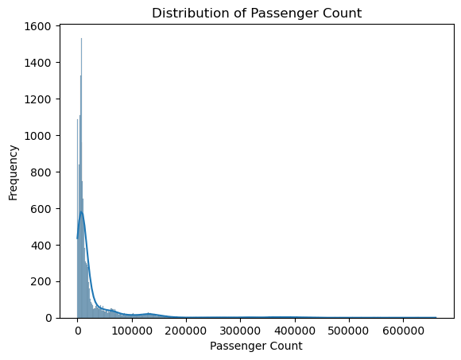

```python
#checking Distribution for numerical column using Histogram
sns.histplot(df['Passenger Count'], kde = True).set_title("Distribution of Passenger Count")
plt.ylabel("Frequency")
```

```python
print('skew:', df['Passenger Count'].skew(axis = 0)) # printing skewness
print('Kurtosis:', df['Passenger Count'].kurtosis(axis = 0)) # printing kurtosis
```

```
skew: 4.360755787688207
Kurtosis: 23.44041657774515
```

- By Obserbing the histogram the distribution is heavily right-skewed
- Skew > 0 -> Right-skewed distribution (positive skewness).
- kurtosis is high it means its leptokurtic. By obserbing histogram also we can tell very sharp peaks means extreme outliers

```python
categorical_features = df.select_dtypes(include = ['object']).columns
categorical_features
```

```
Index(['Operating Airline', 'Operating Airline IATA Code', 'GEO Region',
       'Terminal', 'Boarding Area', 'Month'],
      dtype='object')
```

```python
# Calculating Mode for categorical feature
mode_actegorical = df[categorical_features].mode().T
mode_actegorical
```

|  | 0 |
| --- | --- |
| Operating Airline | United Airlines - Pre 07/01/2013 |
| Operating Airline IATA Code | UA |
| GEO Region | US |
| Terminal | International |
| Boarding Area | A |
| Month | August |

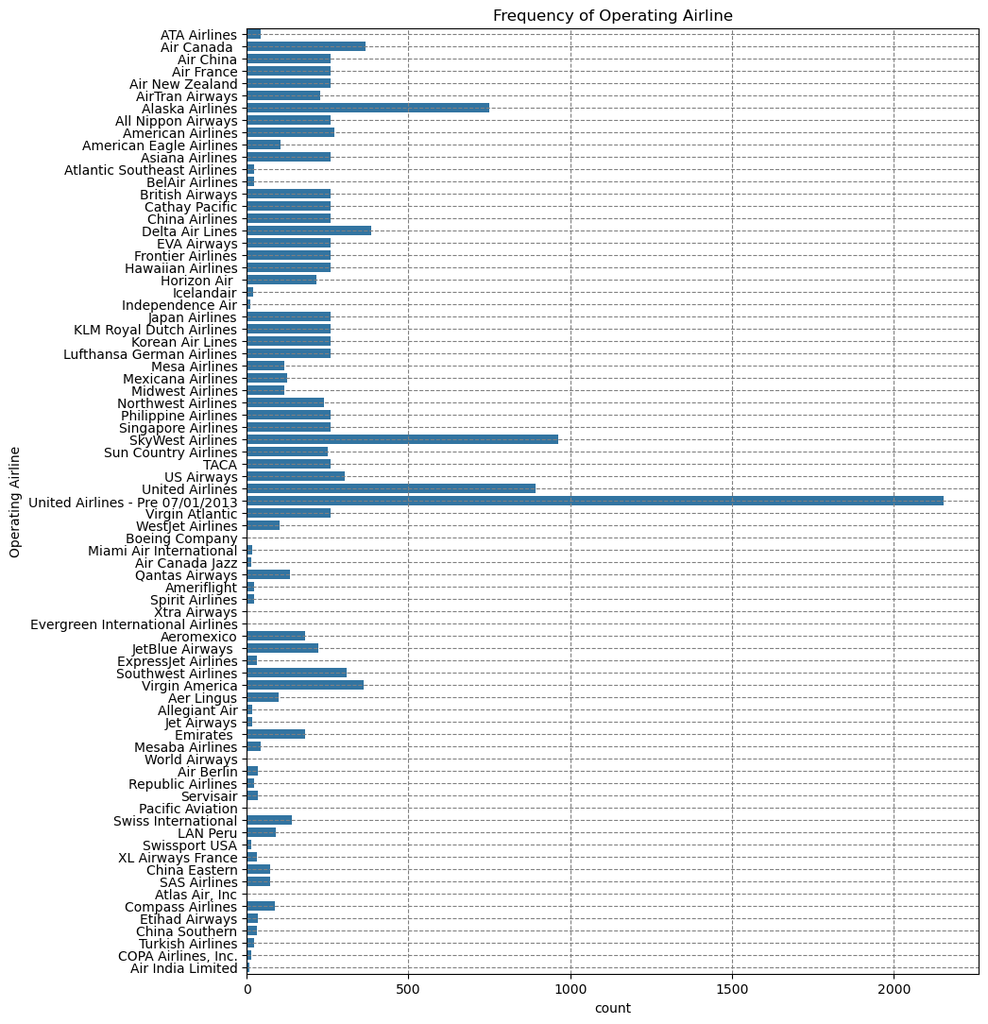

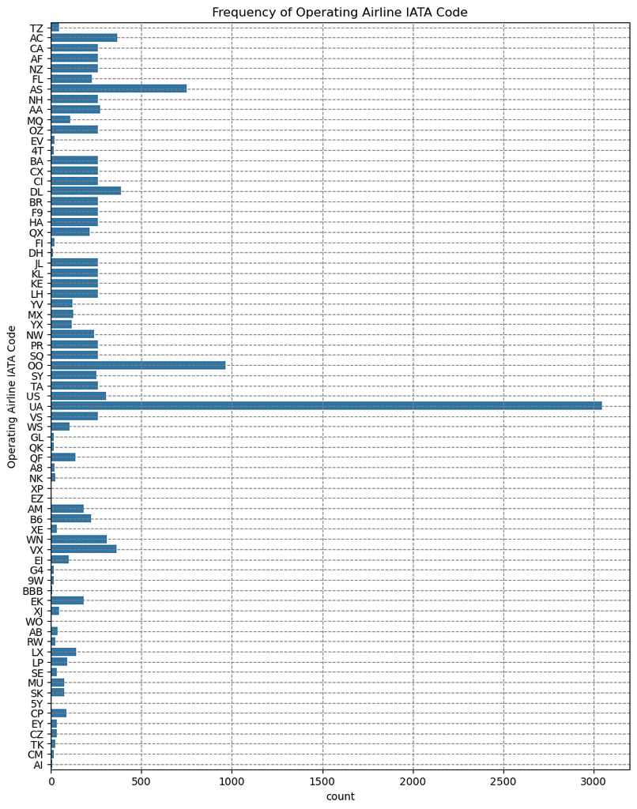

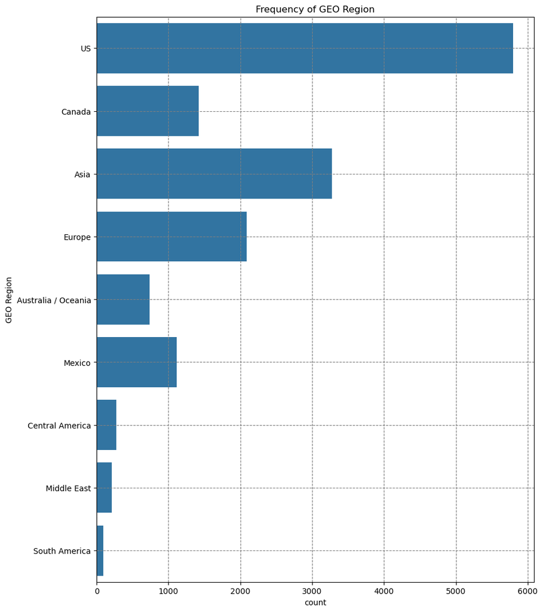

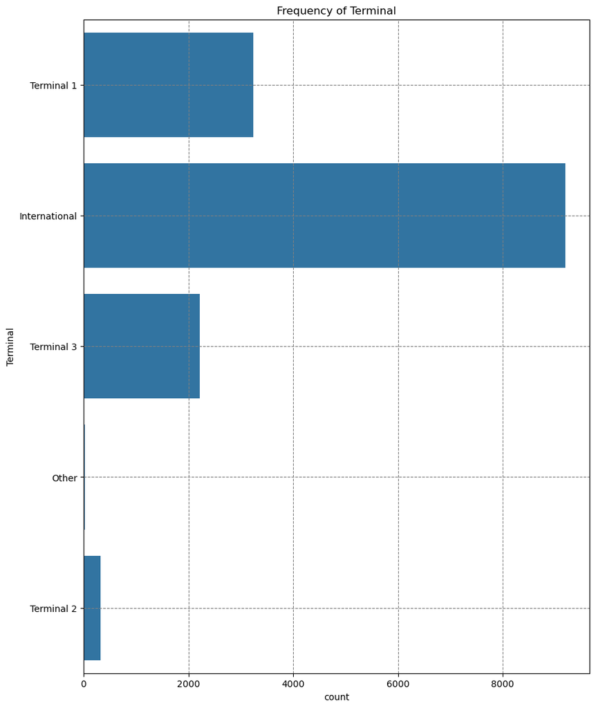

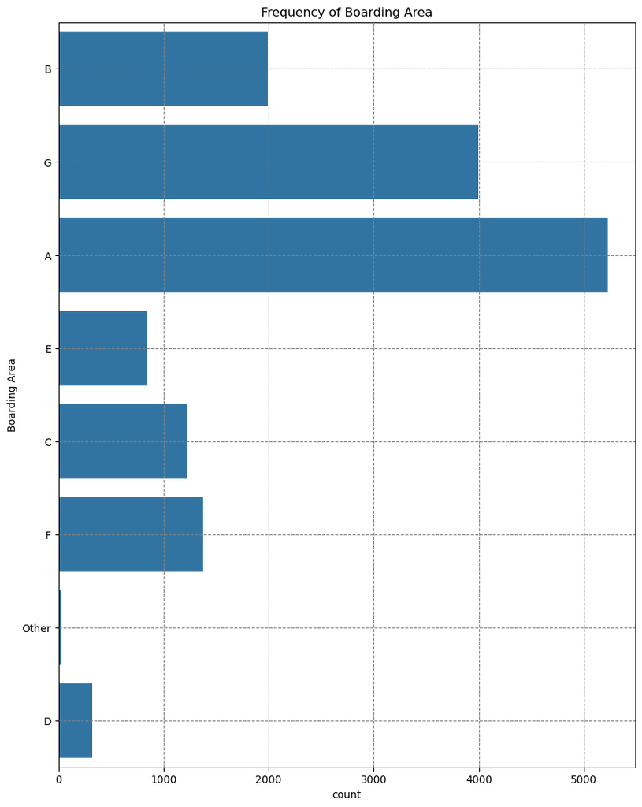

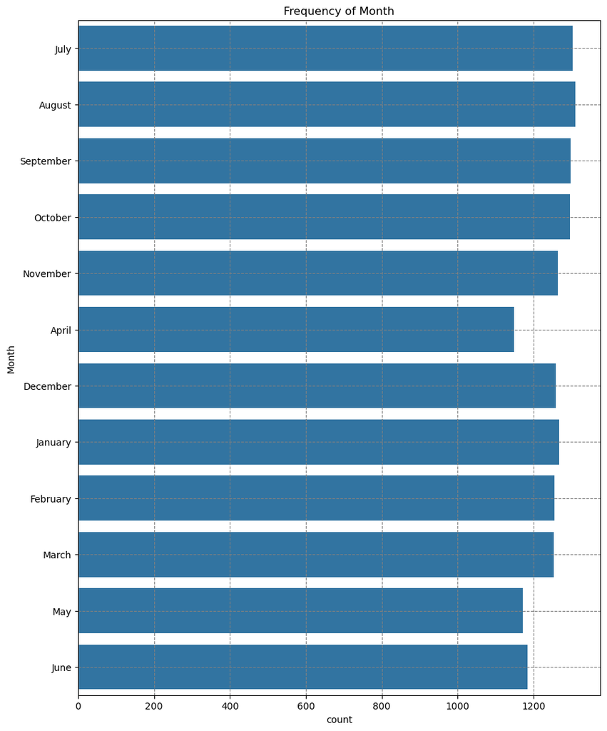

```python
#Checking Frequency using bar plot for categorical value
for i in categorical_features:
    plt.figure(figsize = (10, 13))
    sns.countplot(df[i]).set_title(f'Frequency of {i}')
    plt.grid(True, color = 'grey',ls = '--')
    plt.show()
```

```python
# Grouping Airline by Passenger Count
passenger_by_airline = df.groupby('Operating Airline')['Passenger Count'].sum().sort_values(ascending = False)
passenger_by_airline
```

```
Operating Airline
United Airlines - Pre 07/01/2013    105363917
United Airlines                      64876996
SkyWest Airlines                     35711737
American Airlines                    34588714
Virgin America                       26934738
                                      ...
Xtra Airways                              146
Ameriflight                               110
Atlas Air, Inc                             68
Boeing Company                             18
Evergreen International Airlines            4
Name: Passenger Count, Length: 77, dtype: int64
```

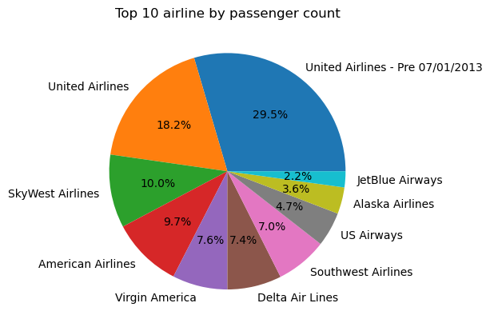

```python
# Ploting Top 10 Airline use by Passenger
plt.pie(passenger_by_airline.head(10),labels = passenger_by_airline.index[:10], autopct='%1.1f%%')
plt.title("Top 10 airline by passenger count")
```

> The airline market in this dataset is heavily dominated by United Airlines, followed by a competitive mix of American, SkyWest, Delta, Virgin America, and Southwest. Smaller airlines like Alaska, JetBlue, and US Airways play important but less dominant roles.

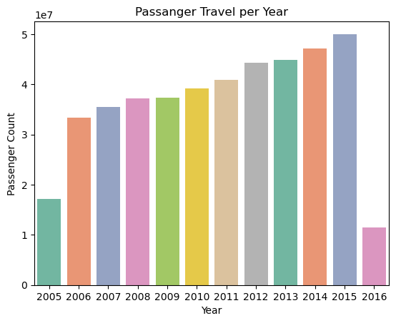

```python
# Grouping year by passenger count to chcek in which year passenger travel the most
group_by_year = df.groupby('Year')['Passenger Count'].sum().sort_values(ascending = False)
sns.barplot(group_by_year, palette = 'Set2')
plt.title("Passanger Travel per Year")
```

- Air travel demand showed strong and consistent growth from 2005 to 2015, with 2015 being the peak year.
- The sudden drop in 2016 indicates incomplete data rather than an actual decline.

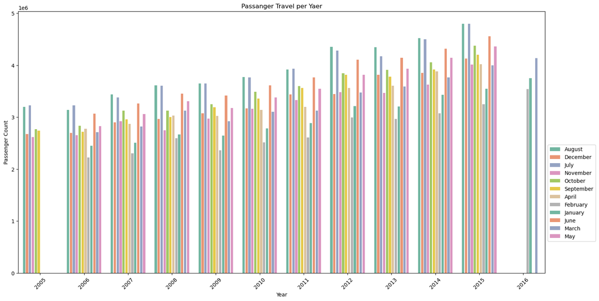

```python
# Grouping year and month by passenger count to chcek in which year and month  passenger travel the most
group_by_year_and_month = df.groupby(['Year', 'Month'])['Passenger Count'].sum().reset_index().sort_values(['Year','Month'])
plt.figure(figsize=(18,9))
sns.barplot(data = group_by_year_and_month, x = 'Year', y = 'Passenger Count', hue = 'Month', palette = 'Set2', gap = 0.2 )
plt.title("Passanger Travel per Yaer")
plt.xticks(rotation=45)
plt.legend(loc='upper left', bbox_to_anchor=(1, 0.5))
plt.show()
```

```python
#Terminal use by airlines
terminal_by_airline = df.groupby(["Operating Airline", "Terminal"])["Passenger Count"].sum().reset_index().sort_values(["Operating Airline", "Terminal"])
terminal_by_airline
```

|  | Operating Airline | Terminal | Passenger Count |
| --- | --- | --- | --- |
| 0 | ATA Airlines | International | 2081 |
| 1 | ATA Airlines | Terminal 1 | 382493 |
| 2 | ATA Airlines | Terminal 3 | 190 |
| 3 | Aer Lingus | International | 431904 |
| 4 | Aeromexico | International | 983488 |
| ... | ... | ... | ... |
| 94 | Virgin Atlantic | International | 2540553 |
| 95 | WestJet Airlines | International | 549830 |
| 96 | World Airways | International | 785 |
| 97 | XL Airways France | International | 68918 |
| 98 | Xtra Airways | International | 146 |

99 rows × 3 columns

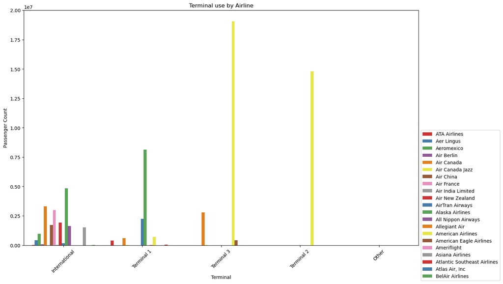

```python
# Ploting Graph for terminal
plt.figure(figsize=(15,9))
sns.barplot(terminal_by_airline.head(30), y = 'Passenger Count', x='Terminal', hue='Operating Airline', palette = 'Set1' )
plt.title("Terminal use by Airline")
plt.legend(loc='upper left', bbox_to_anchor=(1, 0.5))
plt.xticks(rotation=45)
plt.show()
```

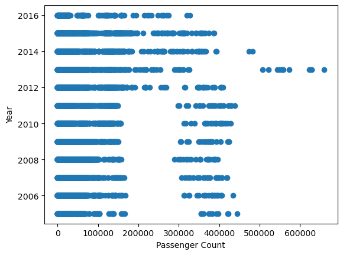

```python
# Ploting Scatter plot to check corelation between passenger count and year
plt.scatter(x = df['Passenger Count'], y = df['Year'])
plt.xlabel("Passenger Count")
plt.ylabel("Year")
```

```python
# group_by_year_and_month = df.groupby(['Year', 'Month'])['Passenger Count'].sum().reset_index().sort_values(['Year','Month'])
# plt.figure(figsize=(18,9))
# sns.lineplot(data = group_by_year_and_month, hue = 'Month', y = 'Passenger Count',x = 'Year', palette = 'Set2')
# plt.title("Passanger Travel per Yaer")
# plt.xticks(rotation=45)
# plt.legend(loc='upper left', bbox_to_anchor=(1, 0.5))
# plt.show()
```

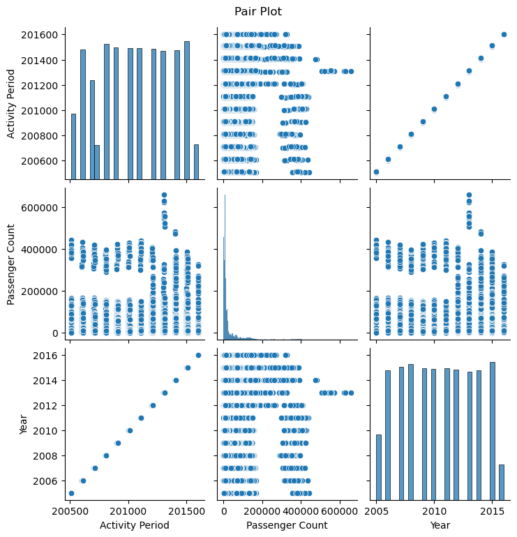

```python
# Using
sns.pairplot(df , height=2.5)
plt.suptitle("Pair Plot",  y=1.02)
plt.show()
```

The pair plot in the image visualizes relationships between three variables: Activity Period, Passenger Count, and Year

```python
df.isnull().sum() # Chceking is there any null
```

```
Activity Period                 0
Operating Airline               0
Operating Airline IATA Code    54
GEO Region                      0
Terminal                        0
Boarding Area                   0
Passenger Count                 0
Year                            0
Month                           0
dtype: int64
```

```python
#Fill the null value with "Unknow" in the column Operating Airline IATA Code
df["Operating Airline IATA Code"].fillna("Unknow", inplace= True)
```

```python
# Chceking info
df.info()
```

```
<class 'pandas.core.frame.DataFrame'>
RangeIndex: 15007 entries, 0 to 15006
Data columns (total 9 columns):
 #   Column                       Non-Null Count  Dtype
---  ------                       --------------  -----
 0   Activity Period              15007 non-null  int64
 1   Operating Airline            15007 non-null  object
 2   Operating Airline IATA Code  15007 non-null  object
 3   GEO Region                   15007 non-null  object
 4   Terminal                     15007 non-null  object
 5   Boarding Area                15007 non-null  object
 6   Passenger Count              15007 non-null  int64
 7   Year                         15007 non-null  int64
 8   Month                        15007 non-null  object
dtypes: int64(3), object(6)
memory usage: 1.0+ MB
```

```python
#checking the duplicate records
duplicates = df[df.duplicated()]
```

```python
duplicates #print the duplicate records
```

|  | Activity Period | Operating Airline | Operating Airline IATA Code | GEO Region | Terminal | Boarding Area | Passenger Count | Year | Month |
| --- | --- | --- | --- | --- | --- | --- | --- | --- | --- |
| 474 | 200511 | ATA Airlines | TZ | Canada | International | A | 284 | 2005 | November |
| 869 | 200602 | Mesa Airlines | YV | US | Terminal 1 | B | 1179 | 2006 | February |
| 1276 | 200606 | Ameriflight | A8 | US | Other | Other | 5 | 2006 | June |
| 1596 | 200608 | Xtra Airways | XP | US | International | A | 73 | 2006 | August |
| 1865 | 200611 | Ameriflight | A8 | US | Other | Other | 1 | 2006 | November |
| 1881 | 200611 | Evergreen International Airlines | EZ | Asia | Other | Other | 2 | 2006 | November |
| 1981 | 200612 | Ameriflight | A8 | US | Other | Other | 4 | 2006 | December |
| 2068 | 200701 | ATA Airlines | TZ | US | International | A | 48 | 2007 | January |
| 2296 | 200703 | Aeromexico | AM | Mexico | International | A | 262 | 2007 | March |
| 4621 | 200810 | Midwest Airlines | YX | US | Terminal 3 | E | 2060 | 2008 | October |
| 6815 | 201005 | Servisair | Unknow | US | International | G | 73 | 2010 | May |
| 6926 | 201006 | Pacific Aviation | Unknow | Europe | International | A | 160 | 2010 | June |
| 7174 | 201008 | Servisair | Unknow | US | International | G | 118 | 2010 | August |
| 7690 | 201101 | Air Canada | AC | Canada | Terminal 3 | E | 18556 | 2011 | January |
| 7748 | 201101 | Servisair | Unknow | US | International | A | 40 | 2011 | January |
| 7973 | 201103 | Servisair | Unknow | US | International | A | 64 | 2011 | March |
| 8794 | 201110 | Servisair | Unknow | US | International | A | 48 | 2011 | October |
| 8796 | 201110 | Servisair | Unknow | Europe | International | A | 16 | 2011 | October |
| 9132 | 201201 | Servisair | Unknow | US | International | A | 77 | 2012 | January |
| 9358 | 201203 | Servisair | Unknow | US | International | A | 51 | 2012 | March |
| 9699 | 201206 | Servisair | Unknow | US | International | A | 62 | 2012 | June |
| 10173 | 201210 | Servisair | Unknow | US | International | A | 57 | 2012 | October |
| 10403 | 201212 | Servisair | Unknow | US | International | A | 57 | 2012 | December |
| 10980 | 201305 | Swissport USA | Unknow | Europe | International | A | 300 | 2013 | May |
| 11211 | 201307 | Swissport USA | Unknow | Europe | International | A | 276 | 2013 | July |
| 11539 | 201310 | Servisair | Unknow | US | International | A | 75 | 2013 | October |
| 11760 | 201312 | Lufthansa German Airlines | LH | Europe | International | G | 16132 | 2013 | December |
| 12445 | 201406 | Republic Airlines | RW | US | Terminal 1 | B | 36 | 2014 | June |
| 13026 | 201411 | Swissport USA | Unknow | Central America | International | A | 234 | 2014 | November |
| 13128 | 201412 | Republic Airlines | RW | US | Terminal 1 | B | 52 | 2014 | December |
| 13332 | 201502 | China Southern | CZ | Asia | International | A | 2311 | 2015 | February |
| 13689 | 201505 | China Southern | CZ | Asia | International | A | 2471 | 2015 | May |

```python
#dropping the duplicates values and reset the index number
df_new = df.drop_duplicates().reset_index(drop = True)
```

```python
df_new
```

|  | Activity Period | Operating Airline | Operating Airline IATA Code | GEO Region | Terminal | Boarding Area | Passenger Count | Year | Month |
| --- | --- | --- | --- | --- | --- | --- | --- | --- | --- |
| 0 | 200507 | ATA Airlines | TZ | US | Terminal 1 | B | 27271 | 2005 | July |
| 1 | 200507 | ATA Airlines | TZ | US | Terminal 1 | B | 29131 | 2005 | July |
| 2 | 200507 | ATA Airlines | TZ | US | Terminal 1 | B | 5415 | 2005 | July |
| 3 | 200507 | Air Canada | AC | Canada | Terminal 1 | B | 35156 | 2005 | July |
| 4 | 200507 | Air Canada | AC | Canada | Terminal 1 | B | 34090 | 2005 | July |
| ... | ... | ... | ... | ... | ... | ... | ... | ... | ... |
| 14970 | 201603 | Virgin America | VX | US | Terminal 2 | D | 194636 | 2016 | March |
| 14971 | 201603 | Virgin America | VX | Mexico | International | A | 4189 | 2016 | March |
| 14972 | 201603 | Virgin America | VX | Mexico | Terminal 2 | D | 4693 | 2016 | March |
| 14973 | 201603 | Virgin Atlantic | VS | Europe | International | A | 12313 | 2016 | March |
| 14974 | 201603 | Virgin Atlantic | VS | Europe | International | A | 10898 | 2016 | March |

14975 rows × 9 columns

```python
df_new.info()
```

```
<class 'pandas.core.frame.DataFrame'>
RangeIndex: 14975 entries, 0 to 14974
Data columns (total 9 columns):
 #   Column                       Non-Null Count  Dtype
---  ------                       --------------  -----
 0   Activity Period              14975 non-null  int64
 1   Operating Airline            14975 non-null  object
 2   Operating Airline IATA Code  14975 non-null  object
 3   GEO Region                   14975 non-null  object
 4   Terminal                     14975 non-null  object
 5   Boarding Area                14975 non-null  object
 6   Passenger Count              14975 non-null  int64
 7   Year                         14975 non-null  int64
 8   Month                        14975 non-null  object
dtypes: int64(3), object(6)
memory usage: 1.0+ MB
```

```python
df_clean = df_new # Storing the clean data
```

```python
df_new = df_new.drop(["Operating Airline IATA Code"], axis = 1) # Drop the Operating Airline IATA Code this is a nominal data
```

```python
df_new = df_new.drop(["Activity Period"], axis = 1) # Drop the Activity Period becasue there  extracted yaer and month column
```

```python
df_new
```

|  | Operating Airline | GEO Region | Terminal | Boarding Area | Passenger Count | Year | Month |
| --- | --- | --- | --- | --- | --- | --- | --- |
| 0 | ATA Airlines | US | Terminal 1 | B | 27271 | 2005 | July |
| 1 | ATA Airlines | US | Terminal 1 | B | 29131 | 2005 | July |
| 2 | ATA Airlines | US | Terminal 1 | B | 5415 | 2005 | July |
| 3 | Air Canada | Canada | Terminal 1 | B | 35156 | 2005 | July |
| 4 | Air Canada | Canada | Terminal 1 | B | 34090 | 2005 | July |
| ... | ... | ... | ... | ... | ... | ... | ... |
| 14970 | Virgin America | US | Terminal 2 | D | 194636 | 2016 | March |
| 14971 | Virgin America | Mexico | International | A | 4189 | 2016 | March |
| 14972 | Virgin America | Mexico | Terminal 2 | D | 4693 | 2016 | March |
| 14973 | Virgin Atlantic | Europe | International | A | 12313 | 2016 | March |
| 14974 | Virgin Atlantic | Europe | International | A | 10898 | 2016 | March |

14975 rows × 7 columns

```python
categorical_features = df_new.select_dtypes(include = ['object']).columns # Extracting categorical column name
categorical_features
```

```
Index(['Operating Airline', 'GEO Region', 'Terminal', 'Boarding Area',
       'Month'],
      dtype='object')
```

```python
# Removing space from String and change first letter capital
def clean_str(x):
    if pd.isna(x):
        return x
    return x.strip().title()

for col in categorical_features:
    df_new[col] = df_new[col].apply(clean_str)
```

```python
df_new.describe()
```

|  | Passenger Count | Year |
| --- | --- | --- |
| count | 14975.000000 | 14975.000000 |
| mean | 29299.987713 | 2010.385242 |
| std | 58367.266344 | 3.137775 |
| min | 1.000000 | 2005.000000 |
| 25% | 5390.000000 | 2008.000000 |
| 50% | 9239.000000 | 2010.000000 |
| 75% | 21190.000000 | 2013.000000 |
| max | 659837.000000 | 2016.000000 |

```python
# Converting month column to month number jan--> 1, feb --> 2 etc..
df_new ['Month_num'] = pd.to_datetime(df_new['Month'], format='%B').dt.month
```

```python
# Again convertig it into month_sin, month_cos because to capture the cyclical nature—i.e., after December, the cycle restarts at January smoothly
df_new['Month_sin'] = np.sin(2 * np.pi * df_new['Month_num'] / 12)
df_new['Month_cos'] = np.cos(2 * np.pi * df_new['Month_num'] / 12)
```

```python
df_new = df_new.drop(['Month'], axis = 1) # drop the month column
```

```python
df_new
```

|  | Operating Airline | GEO Region | Terminal | Boarding Area | Passenger Count | Year | Month_num | Month_sin | Month_cos |
| --- | --- | --- | --- | --- | --- | --- | --- | --- | --- |
| 0 | Ata Airlines | Us | Terminal 1 | B | 27271 | 2005 | 7 | -0.5 | -8.660254e-01 |
| 1 | Ata Airlines | Us | Terminal 1 | B | 29131 | 2005 | 7 | -0.5 | -8.660254e-01 |
| 2 | Ata Airlines | Us | Terminal 1 | B | 5415 | 2005 | 7 | -0.5 | -8.660254e-01 |
| 3 | Air Canada | Canada | Terminal 1 | B | 35156 | 2005 | 7 | -0.5 | -8.660254e-01 |
| 4 | Air Canada | Canada | Terminal 1 | B | 34090 | 2005 | 7 | -0.5 | -8.660254e-01 |
| ... | ... | ... | ... | ... | ... | ... | ... | ... | ... |
| 14970 | Virgin America | Us | Terminal 2 | D | 194636 | 2016 | 3 | 1.0 | 6.123234e-17 |
| 14971 | Virgin America | Mexico | International | A | 4189 | 2016 | 3 | 1.0 | 6.123234e-17 |
| 14972 | Virgin America | Mexico | Terminal 2 | D | 4693 | 2016 | 3 | 1.0 | 6.123234e-17 |
| 14973 | Virgin Atlantic | Europe | International | A | 12313 | 2016 | 3 | 1.0 | 6.123234e-17 |
| 14974 | Virgin Atlantic | Europe | International | A | 10898 | 2016 | 3 | 1.0 | 6.123234e-17 |

14975 rows × 9 columns

```python
numeric_features = df_new.select_dtypes(include = 'int64').columns # Etracting numerical feature
numeric_features
```

```
Index(['Passenger Count', 'Year'], dtype='object')
```

```python
cyclical_features = ['Month_sin', 'Month_cos'] # Etracting cyclic feature
cyclical_features
```

```
['Month_sin', 'Month_cos']
```

```python
categorical_features = df_new.select_dtypes(include = ['object']).columns # Etracting categorical feature
categorical_features
```

```
Index(['Operating Airline', 'GEO Region', 'Terminal', 'Boarding Area'], dtype='object')
```

```
<module 'matplotlib.pyplot' from 'c:\\Users\\ASUS\\anaconda3\\Lib\\site-packages\\matplotlib\\pyplot.py'>
```

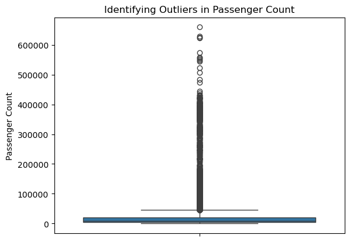

```python
#Checking outlier using box plot
sns.boxplot(df_new['Passenger Count'])
plt.title("Identifying Outliers in Passenger Count")
plt
```

```python
#Finding iqr, q1, q3, and upper whisker and lower whisker and outlier

q1= df_new['Passenger Count'].quantile(0.25)
q3= df_new['Passenger Count'].quantile(0.75)
print(q1, q3)
```

```
5390.0 21190.0
```

```python
#iqr = q3 - q1
iqr = q3 - q1

lower_bound = q1 - 1.5 * iqr
upper_bound = q3 + 1.5 * iqr

#outlier finding
outlier = df_new[(df_new['Passenger Count'] < lower_bound) | (df_new['Passenger Count'] > upper_bound)]
outlier
```

|  | Operating Airline | GEO Region | Terminal | Boarding Area | Passenger Count | Year | Month_num | Month_sin | Month_cos |
| --- | --- | --- | --- | --- | --- | --- | --- | --- | --- |
| 23 | American Airlines | Us | Terminal 3 | E | 166577 | 2005 | 7 | -0.5 | -8.660254e-01 |
| 24 | American Airlines | Us | Terminal 3 | E | 160890 | 2005 | 7 | -0.5 | -8.660254e-01 |
| 39 | Delta Air Lines | Us | Terminal 1 | C | 97510 | 2005 | 7 | -0.5 | -8.660254e-01 |
| 40 | Delta Air Lines | Us | Terminal 1 | C | 93791 | 2005 | 7 | -0.5 | -8.660254e-01 |
| 67 | Northwest Airlines | Us | Terminal 1 | C | 64231 | 2005 | 7 | -0.5 | -8.660254e-01 |
| ... | ... | ... | ... | ... | ... | ... | ... | ... | ... |
| 14951 | United Airlines | Us | Terminal 3 | F | 319873 | 2016 | 3 | 1.0 | 6.123234e-17 |
| 14953 | United Airlines | Asia | International | G | 67286 | 2016 | 3 | 1.0 | 6.123234e-17 |
| 14954 | United Airlines | Asia | International | G | 71388 | 2016 | 3 | 1.0 | 6.123234e-17 |
| 14969 | Virgin America | Us | Terminal 2 | D | 186464 | 2016 | 3 | 1.0 | 6.123234e-17 |
| 14970 | Virgin America | Us | Terminal 2 | D | 194636 | 2016 | 3 | 1.0 | 6.123234e-17 |

2428 rows × 9 columns

```python
#making Pipeline for Outlier treatment, Scaling and encoding for all feature
num_pipeline = Pipeline([
    ('winsor', Winsorizer(capping_method='iqr', tail='both', fold=1.5, variables=['Passenger Count'])),
    ('scaler', StandardScaler())
]) # For numeric feature Winsorization and Standard scaler

cat_pipeline = Pipeline([
    ('onehot', OneHotEncoder(handle_unknown='ignore')),
    ('scaler', StandardScaler(with_mean=False)) # For categorical feature OneHotEncoder and Standard scaler
])

cyc_pipeline = Pipeline([
    ('scaler', StandardScaler())
]) # For cylic feature Standard scaler

preprocessor = ColumnTransformer([
    ('num', num_pipeline, numeric_features),
    ('cyc', cyc_pipeline, cyclical_features),
    ('cat', cat_pipeline, categorical_features)
]) # Final pipeline for preprocessing

preprocessor
```

```
ColumnTransformer(transformers=[('num',
                                 Pipeline(steps=[('winsor',
                                                  Winsorizer(capping_method='iqr',
                                                             fold=1.5,
                                                             tail='both',
                                                             variables=['Passenger '
                                                                        'Count'])),
                                                 ('scaler', StandardScaler())]),
                                 Index(['Passenger Count', 'Year'], dtype='object')),
                                ('cyc',
                                 Pipeline(steps=[('scaler', StandardScaler())]),
                                 ['Month_sin', 'Month_cos']),
                                ('cat',
                                 Pipeline(steps=[('onehot',
                                                  OneHotEncoder(handle_unknown='ignore')),
                                                 ('scaler',
                                                  StandardScaler(with_mean=False))]),
                                 Index(['Operating Airline', 'GEO Region', 'Terminal', 'Boarding Area'], dtype='object'))])
```

```python
# Pass the raw data through pipeline
processed_pipline = preprocessor.fit(df_new)
```